# R Workshop for Education Data Science Lesson 1

Fernando Rodriguez

1/10/2019

## Table of Contents

0. Loading/Installing Libraries
1. More workflow basics
   - Navigating multiple R-Markdown files
   - Commenting within chunks of code
2. Importing and Exploring Data
   - Importing data
   - Getting structure of data
3. the $ sign
4. Vector Types
5. Factors as a special case of numeric vector
   - Changing vector types
6. Dealing with NAs
   - Assigning NAs when importing
   - Figuring out number of NAs
7. Data Reduction
   - Figuing out how we’ll reduce the data

```r
knitr::opts_chunk$set(echo = TRUE)
```

## 0. Loading Libraries

First, let’s load the libraries you will use for this lesson. This is the first thing you should do when writing an R-Markdown document. That way, you ensure that you load all of the necessary libraries prior to running code.

```r
# install.libraries("dplyr") <- installing libraries require double qoutations
library(ggplot2) # <- loading libraries doesn't require double qoutations
library(dplyr) # <- for tibbles
```

## 1. More workflow basics

### Navigating Multiple Markdown Files

You can have several R-Markdown files open. However, if you are using the same variable names across different R-Markdown files, These variables will get overritten.

We will learn more about how to manage differnt R-Markdown files and projects in later lessons.

```r
a <- 6
```

### Commenting out text and code

Sometimes you want to leave a quick comment inside an r-chunk, or would simply like to comment out some code. You can do this by using `#`

```r
# comment
# 2 + 3
```

You can comment-out multiple lines of code by selecting the code and using  
control + shift + c (windows and mac)  
command + shift + c (mac)

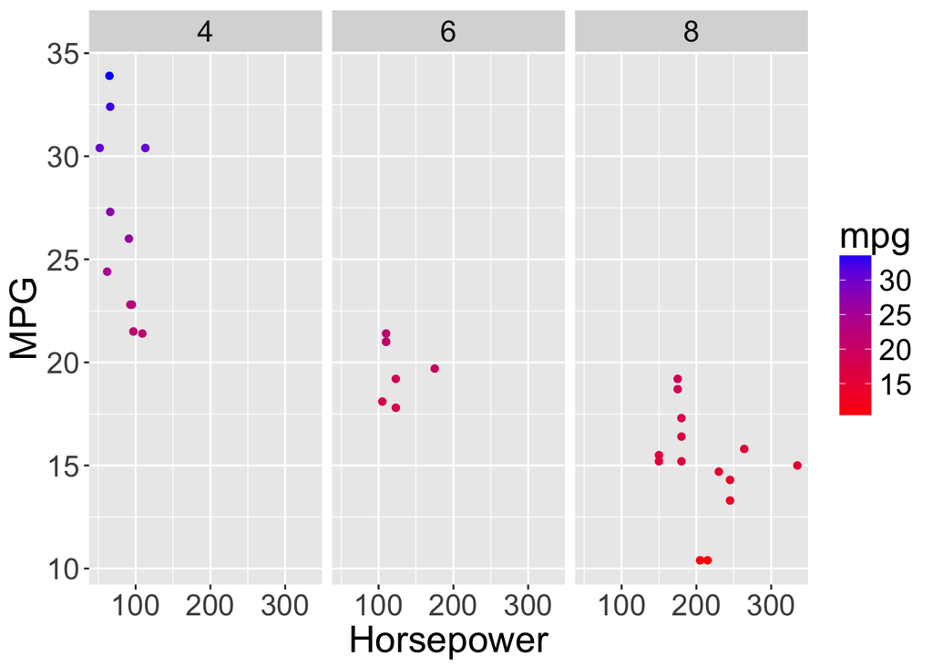

```r
ggplot(mtcars, aes(x = hp, y = mpg, color = mpg)) +
 geom_point() +
  theme(text = element_text(size = 20)) +
  labs(x = "Horsepower", y = "MPG") +
  scale_color_gradient(low = "red", high = "blue") +
  facet_grid(.~cyl)
```

## 2. Importing Data using read.csv()

```r
demodata <- read.csv("/Volumes/GoogleDrive/My Drive/R Workspace/R-for-Ed-Data-Science/Data/Physics Course Demo Data.csv", header = T)
```

### Getting structureof the data

We can use the str()

```r
str(demodata)
```

```
## 'data.frame':    192 obs. of  19 variables:
##  $ roster_randomid          : int  672849 872962 482931 455346 491579 608378 714417 508735 407162 529371 ...
##  $ officialroster           : Factor w/ 3 levels "","NO","Yes": 3 3 3 3 3 3 3 3 3 3 ...
##  $ ingradebookdata          : Factor w/ 2 levels "","Yes": 2 2 2 2 2 2 2 2 2 2 ...
##  $ insurveyparticipatedata  : Factor w/ 2 levels "","Yes": 2 2 2 2 2 2 2 2 2 2 ...
##  $ status                   : Factor w/ 2 levels "","Enrolled": 2 2 2 2 2 2 2 2 2 2 ...
##  $ gender                   : Factor w/ 4 levels "","Female","Male",..: 3 3 3 3 2 2 3 2 3 3 ...
##  $ eth2009rollupforreporting: Factor w/ 6 levels "","Asian / Pacific Islander",..: 4 2 6 2 2 3 2 2 5 2 ...
##  $ agegroup                 : Factor w/ 9 levels "","18","19","20",..: 4 4 8 3 4 3 4 3 4 3 ...
##  $ lowincomeflag            : Factor w/ 4 levels "","N","NAT","Y": 2 2 2 2 4 2 2 2 2 4 ...
##  $ fulltimestatus           : Factor w/ 3 levels "","Full-time",..: 3 3 3 2 2 2 2 3 2 3 ...
##  $ firstgenerationflag      : Factor w/ 5 levels "","MDT","N","NAT",..: 3 3 5 5 5 5 3 5 5 5 ...
##  $ homeprimarylang          : Factor w/ 5 levels "","English only",..: 3 2 5 2 5 2 3 2 5 3 ...
##  $ admissionsstatusdetail   : Factor w/ 4 levels "","Freshman",..: 2 2 4 2 2 2 2 2 2 2 ...
##  $ hsgpa                    : num  4.18 4 NA 4.04 4.14 ...
##  $ transfergpa              : num  NA NA 3.22 NA NA NA NA NA NA NA ...
##  $ gpacumulative            : logi  NA NA NA NA NA NA ...
##  $ firstregacadyr           : Factor w/ 6 levels "","2009-10","2012-13",..: 5 4 6 6 5 5 5 5 5 5 ...
##  $ firstregacadterm         : Factor w/ 2 levels "","Fall": 2 2 2 2 2 2 2 2 2 2 ...
##  $ major1                   : Factor w/ 27 levels "","Anthropology",..: 5 5 19 13 5 21 5 5 5 5 ...
```

## 3. the $ sign

Notice that each variable name has a $ to its left

```r
str(demodata$agegroup)
```

```
##  Factor w/ 9 levels "","18","19","20",..: 4 4 8 3 4 3 4 3 4 3 ...
```

## 3. Vector Types and Classes

A Vector is a fixed-length collection of values

Atomic means that it onl holds data of a single type

- character: “a”, “swc”
- numeric: 2, 15.5
- integer: 2L (the L tells R to store this as an integer)
- logical: TRUE, FALSE
- complex: 1+4i (complex numbers with real and imaginary parts)

```r
str(demodata)
```

```
## 'data.frame':    192 obs. of  19 variables:
##  $ roster_randomid          : int  672849 872962 482931 455346 491579 608378 714417 508735 407162 529371 ...
##  $ officialroster           : Factor w/ 3 levels "","NO","Yes": 3 3 3 3 3 3 3 3 3 3 ...
##  $ ingradebookdata          : Factor w/ 2 levels "","Yes": 2 2 2 2 2 2 2 2 2 2 ...
##  $ insurveyparticipatedata  : Factor w/ 2 levels "","Yes": 2 2 2 2 2 2 2 2 2 2 ...
##  $ status                   : Factor w/ 2 levels "","Enrolled": 2 2 2 2 2 2 2 2 2 2 ...
##  $ gender                   : Factor w/ 4 levels "","Female","Male",..: 3 3 3 3 2 2 3 2 3 3 ...
##  $ eth2009rollupforreporting: Factor w/ 6 levels "","Asian / Pacific Islander",..: 4 2 6 2 2 3 2 2 5 2 ...
##  $ agegroup                 : Factor w/ 9 levels "","18","19","20",..: 4 4 8 3 4 3 4 3 4 3 ...
##  $ lowincomeflag            : Factor w/ 4 levels "","N","NAT","Y": 2 2 2 2 4 2 2 2 2 4 ...
##  $ fulltimestatus           : Factor w/ 3 levels "","Full-time",..: 3 3 3 2 2 2 2 3 2 3 ...
##  $ firstgenerationflag      : Factor w/ 5 levels "","MDT","N","NAT",..: 3 3 5 5 5 5 3 5 5 5 ...
##  $ homeprimarylang          : Factor w/ 5 levels "","English only",..: 3 2 5 2 5 2 3 2 5 3 ...
##  $ admissionsstatusdetail   : Factor w/ 4 levels "","Freshman",..: 2 2 4 2 2 2 2 2 2 2 ...
##  $ hsgpa                    : num  4.18 4 NA 4.04 4.14 ...
##  $ transfergpa              : num  NA NA 3.22 NA NA NA NA NA NA NA ...
##  $ gpacumulative            : logi  NA NA NA NA NA NA ...
##  $ firstregacadyr           : Factor w/ 6 levels "","2009-10","2012-13",..: 5 4 6 6 5 5 5 5 5 5 ...
##  $ firstregacadterm         : Factor w/ 2 levels "","Fall": 2 2 2 2 2 2 2 2 2 2 ...
##  $ major1                   : Factor w/ 27 levels "","Anthropology",..: 5 5 19 13 5 21 5 5 5 5 ...
```

## 4. Factors

Factors in R are stored as a vector of integer values with a corresponding set of character values to use when the factor is displayed Which are some variables that have the wrong vector type?

use as.factor, as.numeric, as.character

```r
demodata$age <- as.numeric(demodata$agegroup)
str(demodata)
```

```
## 'data.frame':    192 obs. of  20 variables:
##  $ roster_randomid          : int  672849 872962 482931 455346 491579 608378 714417 508735 407162 529371 ...
##  $ officialroster           : Factor w/ 3 levels "","NO","Yes": 3 3 3 3 3 3 3 3 3 3 ...
##  $ ingradebookdata          : Factor w/ 2 levels "","Yes": 2 2 2 2 2 2 2 2 2 2 ...
##  $ insurveyparticipatedata  : Factor w/ 2 levels "","Yes": 2 2 2 2 2 2 2 2 2 2 ...
##  $ status                   : Factor w/ 2 levels "","Enrolled": 2 2 2 2 2 2 2 2 2 2 ...
##  $ gender                   : Factor w/ 4 levels "","Female","Male",..: 3 3 3 3 2 2 3 2 3 3 ...
##  $ eth2009rollupforreporting: Factor w/ 6 levels "","Asian / Pacific Islander",..: 4 2 6 2 2 3 2 2 5 2 ...
##  $ agegroup                 : Factor w/ 9 levels "","18","19","20",..: 4 4 8 3 4 3 4 3 4 3 ...
##  $ lowincomeflag            : Factor w/ 4 levels "","N","NAT","Y": 2 2 2 2 4 2 2 2 2 4 ...
##  $ fulltimestatus           : Factor w/ 3 levels "","Full-time",..: 3 3 3 2 2 2 2 3 2 3 ...
##  $ firstgenerationflag      : Factor w/ 5 levels "","MDT","N","NAT",..: 3 3 5 5 5 5 3 5 5 5 ...
##  $ homeprimarylang          : Factor w/ 5 levels "","English only",..: 3 2 5 2 5 2 3 2 5 3 ...
##  $ admissionsstatusdetail   : Factor w/ 4 levels "","Freshman",..: 2 2 4 2 2 2 2 2 2 2 ...
##  $ hsgpa                    : num  4.18 4 NA 4.04 4.14 ...
##  $ transfergpa              : num  NA NA 3.22 NA NA NA NA NA NA NA ...
##  $ gpacumulative            : logi  NA NA NA NA NA NA ...
##  $ firstregacadyr           : Factor w/ 6 levels "","2009-10","2012-13",..: 5 4 6 6 5 5 5 5 5 5 ...
##  $ firstregacadterm         : Factor w/ 2 levels "","Fall": 2 2 2 2 2 2 2 2 2 2 ...
##  $ major1                   : Factor w/ 27 levels "","Anthropology",..: 5 5 19 13 5 21 5 5 5 5 ...
##  $ age                      : num  4 4 8 3 4 3 4 3 4 3 ...
```

```r
demodata$age <- as.numeric(as.character(demodata$agegroup))
str(demodata)
```

```
## 'data.frame':    192 obs. of  20 variables:
##  $ roster_randomid          : int  672849 872962 482931 455346 491579 608378 714417 508735 407162 529371 ...
##  $ officialroster           : Factor w/ 3 levels "","NO","Yes": 3 3 3 3 3 3 3 3 3 3 ...
##  $ ingradebookdata          : Factor w/ 2 levels "","Yes": 2 2 2 2 2 2 2 2 2 2 ...
##  $ insurveyparticipatedata  : Factor w/ 2 levels "","Yes": 2 2 2 2 2 2 2 2 2 2 ...
##  $ status                   : Factor w/ 2 levels "","Enrolled": 2 2 2 2 2 2 2 2 2 2 ...
##  $ gender                   : Factor w/ 4 levels "","Female","Male",..: 3 3 3 3 2 2 3 2 3 3 ...
##  $ eth2009rollupforreporting: Factor w/ 6 levels "","Asian / Pacific Islander",..: 4 2 6 2 2 3 2 2 5 2 ...
##  $ agegroup                 : Factor w/ 9 levels "","18","19","20",..: 4 4 8 3 4 3 4 3 4 3 ...
##  $ lowincomeflag            : Factor w/ 4 levels "","N","NAT","Y": 2 2 2 2 4 2 2 2 2 4 ...
##  $ fulltimestatus           : Factor w/ 3 levels "","Full-time",..: 3 3 3 2 2 2 2 3 2 3 ...
##  $ firstgenerationflag      : Factor w/ 5 levels "","MDT","N","NAT",..: 3 3 5 5 5 5 3 5 5 5 ...
##  $ homeprimarylang          : Factor w/ 5 levels "","English only",..: 3 2 5 2 5 2 3 2 5 3 ...
##  $ admissionsstatusdetail   : Factor w/ 4 levels "","Freshman",..: 2 2 4 2 2 2 2 2 2 2 ...
##  $ hsgpa                    : num  4.18 4 NA 4.04 4.14 ...
##  $ transfergpa              : num  NA NA 3.22 NA NA NA NA NA NA NA ...
##  $ gpacumulative            : logi  NA NA NA NA NA NA ...
##  $ firstregacadyr           : Factor w/ 6 levels "","2009-10","2012-13",..: 5 4 6 6 5 5 5 5 5 5 ...
##  $ firstregacadterm         : Factor w/ 2 levels "","Fall": 2 2 2 2 2 2 2 2 2 2 ...
##  $ major1                   : Factor w/ 27 levels "","Anthropology",..: 5 5 19 13 5 21 5 5 5 5 ...
##  $ age                      : num  20 20 24 19 20 19 20 19 20 19 ...
```

## 5. Dealing with NAs

```r
demodata2 <- read.csv("/Volumes/GoogleDrive/My Drive/R Workspace/R-for-Ed-Data-Science/Data/Physics Course Demo Data.csv", header = T,
                     na.strings=c("",NA))
```

# But wait, don’t I want to know what the NAs are?

How can we find out what the function table() can do, and can we find some script that displays the NAs?

```r
table(demodata$gender, useNA = ("always"))
```

```
##
##                Female       Male Not stated       <NA>
##         33         91         67          1          0
```

overwriting original data import, but now declaring how to deal with empty cells

```r
demodata <- read.csv("/Volumes/GoogleDrive/My Drive/R Workspace/R-for-Ed-Data-Science/Data/Physics Course Demo Data.csv", header = T,
                     na.strings=c("",NA))
```

## Exploring our data

### Figuring out what data we have

## Some platting

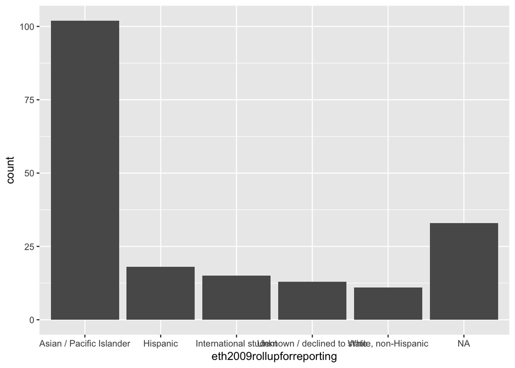

```r
ggplot(demodata, aes(x = eth2009rollupforreporting)) + geom_histogram(stat = "count")
```

make histogram horisontal using coord_flip()

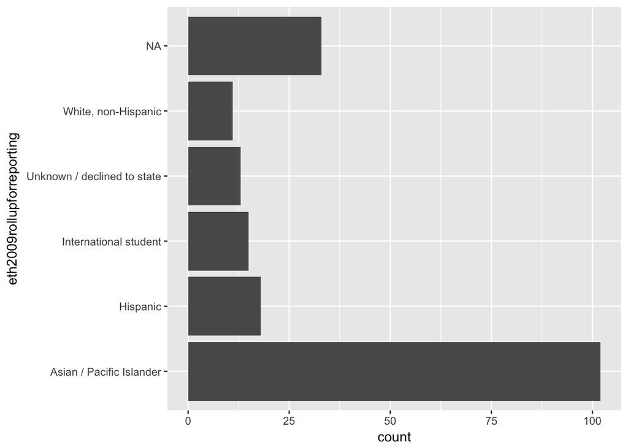

```r
ggplot(demodata, aes(x = eth2009rollupforreporting )) + geom_histogram(stat = "count") +
  coord_flip()
```

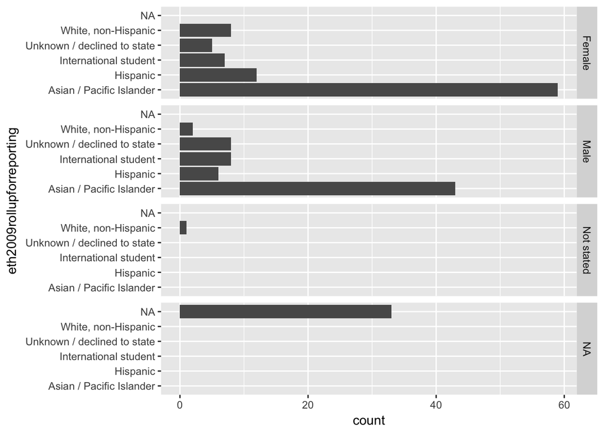

```r
ggplot(demodata, aes(x = eth2009rollupforreporting )) + geom_histogram(stat = "count") +
  coord_flip() + facet_grid(gender ~.)
```

# Let’s look at hsgpa

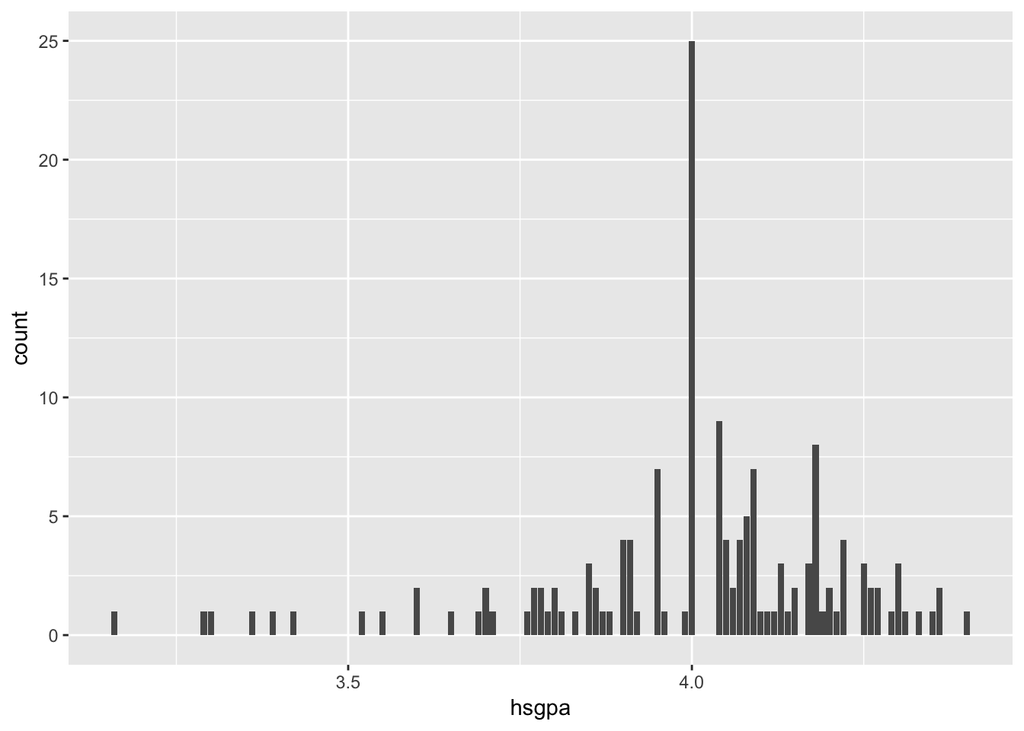

```r
ggplot(demodata, aes(x = hsgpa)) + geom_histogram(stat = "count")
```

```r
table(demodata$hsgpa, useNA = ("always"))
```

```
##
## 3.1600001      3.29       3.3 3.3599999 3.3900001 3.4200001      3.52
##         1         1         1         1         1         1         1
##      3.55 3.5999999 3.6500001 3.6900001       3.7      3.71      3.76
##         1         2         1         1         2         1         1
##      3.77      3.78      3.79       3.8 3.8099999 3.8299999 3.8499999
##         2         2         1         2         1         1         3
## 3.8599999 3.8699999 3.8800001 3.9000001 3.9100001 3.9200001      3.95
##         2         1         1         4         4         1         7
##      3.96      3.99         4      4.04 4.0500002 4.0599999 4.0700002
##         1         1        25         9         4         2         4
## 4.0799999 4.0900002 4.0999999 4.1100001 4.1199999 4.1300001 4.1399999
##         5         7         1         1         1         3         1
## 4.1500001 4.1700001 4.1799998 4.1900001 4.1999998      4.21 4.2199998
##         2         3         8         1         2         1         4
##      4.25 4.2600002      4.27      4.29 4.3000002 4.3099999 4.3299999
##         3         2         2         1         3         1         1
## 4.3499999 4.3600001 4.4000001      <NA>
##         1         2         1        41
```

## Important data reductiontask

We want to know what our sample should be when we conduct some analyses We know we have missing data, but can we find a variable that gives us a reason for all of this missing data

The next library will help us understand this… and change your life.

```r
library(summarytools)
print(dfSummary(demodata), method = 'rmarkdown')
```

Data Frame Summary

demodata

**N**: 192

| **No** | **Variable** | **Stats / Values** | **Freqs (% of Valid)** | **Graph** | **Valid** | **Missing** |
| --- | --- | --- | --- | --- | --- | --- |
| 1 | roster_randomid [integer] | mean (sd) : 514434.11 (243939.78) min < med < max : 104500 < 543478 < 994588 IQR (CV) : 409408.75 (0.47) | 192 distinct values |  | 192 (100%) | 0 (0%) |
| 2 | officialroster [factor] | 1. NO 2. Yes | 14 (7.4%) 176 (92.6%) |  | 190 (98.96%) | 2 (1.04%) |
| 3 | ingradebookdata [factor] | 1. Yes | 176 (100.0%) |  | 176 (91.67%) | 16 (8.33%) |
| 4 | insurveyparticipatedata [factor] | 1. Yes | 190 (100.0%) |  | 190 (98.96%) | 2 (1.04%) |
| 5 | status [factor] | 1. Enrolled | 176 (100.0%) |  | 176 (91.67%) | 16 (8.33%) |
| 6 | gender [factor] | 1. Female 2. Male 3. Not stated | 91 (57.2%) 67 (42.1%) 1 (0.6%) |  | 159 (82.81%) | 33 (17.19%) |
| 7 | eth2009rollupforreporting [factor] | 1. Asian / Pacific Islander 2. Hispanic 3. International student 4. Unknown / declined to sta 5. White, non-Hispanic | 102 (64.1%) 18 (11.3%) 15 (9.4%) 13 (8.2%) 11 (6.9%) |  | 159 (82.81%) | 33 (17.19%) |
| 8 | agegroup [factor] | 1. 18 2. 19 3. 20 4. 21 5. 22 6. 23 7. 24 8. 25-29 | 6 (3.8%) 59 (37.1%) 67 (42.1%) 17 (10.7%) 6 (3.8%) 1 (0.6%) 1 (0.6%) 2 (1.3%) |  | 159 (82.81%) | 33 (17.19%) |
| 9 | lowincomeflag [factor] | 1. N 2. NAT 3. Y | 102 (64.1%) 2 (1.3%) 55 (34.6%) |  | 159 (82.81%) | 33 (17.19%) |
| 10 | fulltimestatus [factor] | 1. Full-time 2. Part-time | 93 (58.5%) 66 (41.5%) |  | 159 (82.81%) | 33 (17.19%) |
| 11 | firstgenerationflag [factor] | 1. MDT 2. N 3. NAT 4. Y | 7 (4.4%) 77 (48.4%) 2 (1.3%) 73 (45.9%) |  | 159 (82.81%) | 33 (17.19%) |
| 12 | homeprimarylang [factor] | 1. English only 2. English/non-English 3. Missing data 4. Non-English | 37 (23.3%) 67 (42.1%) 2 (1.3%) 53 (33.3%) |  | 159 (82.81%) | 33 (17.19%) |
| 13 | admissionsstatusdetail [factor] | 1. Freshman 2. Not applicable 3. Transfer | 151 (95.0%) 2 (1.3%) 6 (3.8%) |  | 159 (82.81%) | 33 (17.19%) |
| 14 | hsgpa [numeric] | mean (sd) : 4 (0.22) min < med < max : 3.16 < 4.04 < 4.4 IQR (CV) : 0.23 (0.06) | 59 distinct values |  | 151 (78.65%) | 41 (21.35%) |
| 15 | transfergpa [numeric] | mean (sd) : 3.33 (0.28) min < med < max : 3.01 < 3.25 < 3.71 IQR (CV) : 0.38 (0.08) | 3.01 : 1 (16.7%) 3.14! : 1 (16.7%) 3.22 : 1 (16.7%) 3.28 : 1 (16.7%) 3.63! : 1 (16.7%) 3.71 : 1 (16.7%) ! rounded |  | 6 (3.12%) | 186 (96.88%) |
| 16 | gpacumulative [logical] |  | All NA's |  | 0 (0%) | 192 (100%) |
| 17 | firstregacadyr [factor] | 1. 2009-10 2. 2012-13 3. 2013-14 4. 2014-15 5. 2015-16 | 1 (0.6%) 5 (3.1%) 21 (13.2%) 109 (68.5%) 23 (14.5%) |  | 159 (82.81%) | 33 (17.19%) |
| 18 | firstregacadterm [factor] | 1. Fall | 159 (100.0%) |  | 159 (82.81%) | 33 (17.19%) |
| 19 | major1 [factor] | 1. Anthropology 2. Art 3. Art History 4. Biological Sciences 5. Biology/Education 6. Business Administration 7. Business Economics 8. Computer Game Science 9. Computer Science 10. Dance [ 16 others ] | 1 (0.6%) 2 (1.3%) 1 (0.6%) 89 (56.0%) 1 (0.6%) 1 (0.6%) 1 (0.6%) 6 (3.8%) 5 (3.1%) 3 (1.9%) 49 (30.8%) |  | 159 (82.81%) | 33 (17.19%) |

Generated by summarytools 0.8.8 ([R](https://www.r-project.org/) version 3.4.3)  
2019-01-17

## Using logical operators to subset rows of dataframes

```r
demodata2$agegroup > 30
```

```
##   [1] NA NA NA NA NA NA NA NA NA NA NA NA NA NA NA NA NA NA NA NA NA NA NA
##  [24] NA NA NA NA NA NA NA NA NA NA NA NA NA NA NA NA NA NA NA NA NA NA NA
##  [47] NA NA NA NA NA NA NA NA NA NA NA NA NA NA NA NA NA NA NA NA NA NA NA
##  [70] NA NA NA NA NA NA NA NA NA NA NA NA NA NA NA NA NA NA NA NA NA NA NA
##  [93] NA NA NA NA NA NA NA NA NA NA NA NA NA NA NA NA NA NA NA NA NA NA NA
## [116] NA NA NA NA NA NA NA NA NA NA NA NA NA NA NA NA NA NA NA NA NA NA NA
## [139] NA NA NA NA NA NA NA NA NA NA NA NA NA NA NA NA NA NA NA NA NA NA NA
## [162] NA NA NA NA NA NA NA NA NA NA NA NA NA NA NA NA NA NA NA NA NA NA NA
## [185] NA NA NA NA NA NA NA NA
```

```r
demodata2
```

[output not shown]

[output cut: 950 more lines]

```r
head(demodata2)
```

```
##   roster_randomid officialroster ingradebookdata insurveyparticipatedata
## 1          672849            Yes             Yes                     Yes
## 2          872962            Yes             Yes                     Yes
## 3          482931            Yes             Yes                     Yes
## 4          455346            Yes             Yes                     Yes
## 5          491579            Yes             Yes                     Yes
## 6          608378            Yes             Yes                     Yes
##     status gender eth2009rollupforreporting agegroup lowincomeflag
## 1 Enrolled   Male     International student       20             N
## 2 Enrolled   Male  Asian / Pacific Islander       20             N
## 3 Enrolled   Male       White, non-Hispanic       24             N
## 4 Enrolled   Male  Asian / Pacific Islander       19             N
## 5 Enrolled Female  Asian / Pacific Islander       20             Y
## 6 Enrolled Female                  Hispanic       19             N
##   fulltimestatus firstgenerationflag     homeprimarylang
```

[output cut: 20 more lines]